# Project Part I - Dataset Exploration of Loan Data from Prosper, a Peer-to-Peer Loan Facilitation Company.

## by Chimmuanya Mogbo

- Introduction
- Preliminary Wrangling
- Univariate Exploration
- Bivariate Exploration
- Multivariate Exploration
- Conclusions

## Introduction

- This data set contains 113,937 loans with 81 variables on each loan form Prosper, an online peer-to-peer lending marketplace based in the United States.
- This data is contained in a csv file downloadable from a udacity-hosted page.

```python
# import all packages and set plots to be embedded inline
import numpy as np
import pandas as pd
import matplotlib.pyplot as plt
import seaborn as sb
#import math
from random import randrange

%matplotlib inline
```

## Preliminary Wrangling

- Data Assessment for Quality and Tidiness
- Data Cleaning

### Data Assessment for Quality and Tidiness

**Import the Already Provided CSV file and Briefly Explore the Structure and Properties.**

```python
# import the dataset from the CSV file
loan_df = pd.read_csv('prosperLoanData.csv')
loan_df.shape
```

```
(113937, 81)
```

```python
loan_df.head(3)
```

|  | ListingKey | ListingNumber | ListingCreationDate | CreditGrade | Term | LoanStatus | ClosedDate | BorrowerAPR | BorrowerRate | LenderYield | ... | LP_ServiceFees | LP_CollectionFees | LP_GrossPrincipalLoss | LP_NetPrincipalLoss | LP_NonPrincipalRecoverypayments | PercentFunded | Recommendations | InvestmentFromFriendsCount | InvestmentFromFriendsAmount | Investors |
| --- | --- | --- | --- | --- | --- | --- | --- | --- | --- | --- | --- | --- | --- | --- | --- | --- | --- | --- | --- | --- | --- |
| 0 | 1021339766868145413AB3B | 193129 | 2007-08-26 19:09:29.263000000 | C | 36 | Completed | 2009-08-14 00:00:00 | 0.16516 | 0.158 | 0.138 | ... | -133.18 | 0.0 | 0.0 | 0.0 | 0.0 | 1.0 | 0 | 0 | 0.0 | 258 |
| 1 | 10273602499503308B223C1 | 1209647 | 2014-02-27 08:28:07.900000000 | NaN | 36 | Current | NaN | 0.12016 | 0.092 | 0.082 | ... | 0.00 | 0.0 | 0.0 | 0.0 | 0.0 | 1.0 | 0 | 0 | 0.0 | 1 |
| 2 | 0EE9337825851032864889A | 81716 | 2007-01-05 15:00:47.090000000 | HR | 36 | Completed | 2009-12-17 00:00:00 | 0.28269 | 0.275 | 0.240 | ... | -24.20 | 0.0 | 0.0 | 0.0 | 0.0 | 1.0 | 0 | 0 | 0.0 | 41 |

3 rows × 81 columns

```python
# get general info on the dataset
loan_df.info()
```

```
<class 'pandas.core.frame.DataFrame'>
RangeIndex: 113937 entries, 0 to 113936
Data columns (total 81 columns):
 #   Column                               Non-Null Count   Dtype
---  ------                               --------------   -----
 0   ListingKey                           113937 non-null  object
 1   ListingNumber                        113937 non-null  int64
 2   ListingCreationDate                  113937 non-null  object
 3   CreditGrade                          28953 non-null   object
 4   Term                                 113937 non-null  int64
 5   LoanStatus                           113937 non-null  object
 6   ClosedDate                           55089 non-null   object
 7   BorrowerAPR                          113912 non-null  float64
 8   BorrowerRate                         113937 non-null  float64
 9   LenderYield                          113937 non-null  float64
```

[output cut: 73 more lines]

1. The following variables have many missing values: TotalProsperLoans, TotalProsperPaymentsBilled, OnTimeProsperPayments, ProsperPaymentsLessThanOneMonthLate, ProsperPaymentsOneMonthPlusLate, ProsperPrincipalBorrowed, ProsperPrincipalOutstanding, ScorexChangeAtTimeOfListing, and LoanFirstDefaultedCycleNumber.
2. Becaause of the sheer number of variables and time constraints, I intend to explore relationships and trends only among a limited number of variables (about 20).
3. These include: ListingNumber, ListingCreationDate, Term, LoanStatus, BorrowerState, Occupation, EmploymentStatus, EmploymentStatusDuration, IsBorrowerHomeowner, DebtToIncomeRatio, IncomeRange, IncomeVerifiable, StatedMonthlyIncome, BorrowerAPR, BorrowerRate, [CreditGrade, ProsperRating (numeric), ProsperRating (Alpha)], LenderYield, ListingCategory, Investors, InvestmentFromFriendsAmount, InvestmentFromFriendsCount
- The variables in square brackets all represent the same quantity.

```python
# create a smaller dataset with these select variables for the purpose of further data cleaning.

# first create a list containing the variables of interest
variables_to_explore = ['ListingNumber', 'ListingCreationDate', 'Term', 'LoanStatus', 'BorrowerState', 'Occupation', 'EmploymentStatus', 'EmploymentStatusDuration', 'IsBorrowerHomeowner', 'DebtToIncomeRatio', 'IncomeRange', 'IncomeVerifiable', 'StatedMonthlyIncome', 'BorrowerAPR', 'BorrowerRate', 'CreditGrade', 'ProsperRating (numeric)', 'ProsperRating (Alpha)', 'LenderYield', 'ListingCategory (numeric)', 'InvestmentFromFriendsCount', 'InvestmentFromFriendsAmount', 'Investors']

# create the smaller dataset
loan_df_subset = loan_df[variables_to_explore]
```

```python
#confirm `loan_df_subset` creation
loan_df_subset.sample(3)
```

|  | ListingNumber | ListingCreationDate | Term | LoanStatus | BorrowerState | Occupation | EmploymentStatus | EmploymentStatusDuration | IsBorrowerHomeowner | DebtToIncomeRatio | ... | BorrowerAPR | BorrowerRate | CreditGrade | ProsperRating (numeric) | ProsperRating (Alpha) | LenderYield | ListingCategory (numeric) | InvestmentFromFriendsCount | InvestmentFromFriendsAmount | Investors |
| --- | --- | --- | --- | --- | --- | --- | --- | --- | --- | --- | --- | --- | --- | --- | --- | --- | --- | --- | --- | --- | --- |
| 49783 | 852302 | 2013-07-26 14:20:01.163000000 | 60 | Current | CT | Retail Management | Employed | 291.0 | True | 0.05 | ... | 0.17522 | 0.1519 | NaN | 5.0 | B | 0.1419 | 1 | 0 | 0.0 | 169 |
| 95649 | 113206 | 2007-03-19 19:29:07.740000000 | 36 | Completed | NaN | Military Officer | Full-time | 189.0 | False | 0.19 | ... | 0.10692 | 0.1000 | AA | NaN | NaN | 0.0950 | 0 | 1 | 500.0 | 518 |
| 57189 | 619562 | 2012-08-02 09:31:52.657000000 | 60 | Chargedoff | TN | Executive | Employed | 532.0 | False | 0.56 | ... | 0.29464 | 0.2684 | NaN | 3.0 | D | 0.2584 | 3 | 0 | 0.0 | 28 |

3 rows × 23 columns

```python
# confirm number of variables
loan_df_subset.info()
```

```
<class 'pandas.core.frame.DataFrame'>
RangeIndex: 113937 entries, 0 to 113936
Data columns (total 23 columns):
 #   Column                       Non-Null Count   Dtype
---  ------                       --------------   -----
 0   ListingNumber                113937 non-null  int64
 1   ListingCreationDate          113937 non-null  object
 2   Term                         113937 non-null  int64
 3   LoanStatus                   113937 non-null  object
 4   BorrowerState                108422 non-null  object
 5   Occupation                   110349 non-null  object
 6   EmploymentStatus             111682 non-null  object
 7   EmploymentStatusDuration     106312 non-null  float64
 8   IsBorrowerHomeowner          113937 non-null  bool
 9   DebtToIncomeRatio            105383 non-null  float64
 10  IncomeRange                  113937 non-null  object
 11  IncomeVerifiable             113937 non-null  bool
 12  StatedMonthlyIncome          113937 non-null  float64
 13  BorrowerAPR                  113912 non-null  float64
 14  BorrowerRate                 113937 non-null  float64
 15  CreditGrade                  28953 non-null   object
 16  ProsperRating (numeric)      84853 non-null   float64
 17  ProsperRating (Alpha)        84853 non-null   object
 18  LenderYield                  113937 non-null  float64
 19  ListingCategory (numeric)    113937 non-null  int64
 20  InvestmentFromFriendsCount   113937 non-null  int64
 21  InvestmentFromFriendsAmount  113937 non-null  float64
 22  Investors                    113937 non-null  int64
dtypes: bool(2), float64(8), int64(5), object(8)
memory usage: 18.5+ MB
```

```python
# check possible categorical variables for unique values
cat_vars = ['LoanStatus', 'BorrowerState', 'Occupation', 'EmploymentStatus']
for var in cat_vars:
    print ('{0}: {1}'.format(var, loan_df_subset[var].unique()))
```

```
LoanStatus: ['Completed' 'Current' 'Past Due (1-15 days)' 'Defaulted' 'Chargedoff'
 'Past Due (16-30 days)' 'Cancelled' 'Past Due (61-90 days)'
 'Past Due (31-60 days)' 'Past Due (91-120 days)' 'FinalPaymentInProgress'
 'Past Due (>120 days)']
BorrowerState: ['CO' 'GA' 'MN' 'NM' 'KS' 'CA' 'IL' 'MD' nan 'AL' 'AZ' 'VA' 'FL' 'PA' 'OR'
 'MI' 'NY' 'LA' 'WI' 'OH' 'NC' 'WA' 'NV' 'NJ' 'TX' 'AR' 'SC' 'DE' 'MO'
 'NE' 'UT' 'DC' 'MA' 'CT' 'IN' 'KY' 'OK' 'MS' 'WV' 'RI' 'TN' 'ID' 'MT'
 'HI' 'NH' 'VT' 'WY' 'ME' 'AK' 'IA' 'SD' 'ND']
Occupation: ['Other' 'Professional' 'Skilled Labor' 'Executive' 'Sales - Retail'
 'Laborer' 'Food Service' 'Fireman' 'Waiter/Waitress' 'Construction'
 'Computer Programmer' 'Sales - Commission' 'Retail Management'
 'Engineer - Mechanical' 'Military Enlisted' 'Clerical' nan 'Teacher'
 'Clergy' 'Accountant/CPA' 'Attorney' 'Nurse (RN)' 'Analyst'
 "Nurse's Aide" 'Investor' 'Realtor' 'Flight Attendant' 'Nurse (LPN)'
 'Military Officer' 'Food Service Management' 'Truck Driver'
 'Administrative Assistant' 'Police Officer/Correction Officer'
 'Social Worker' 'Tradesman - Mechanic' 'Medical Technician' 'Professor'
 'Postal Service' 'Civil Service' 'Pharmacist' 'Tradesman - Electrician'
 'Scientist' 'Dentist' 'Engineer - Electrical' 'Architect' 'Landscaping'
 'Tradesman - Carpenter' 'Bus Driver' 'Tradesman - Plumber'
 'Engineer - Chemical' 'Doctor' 'Chemist' 'Student - College Senior'
 'Principal' "Teacher's Aide" 'Pilot - Private/Commercial' 'Religious'
 'Homemaker' 'Student - College Graduate Student'
 'Student - Technical School' 'Psychologist' 'Biologist'
 'Student - College Sophomore' 'Judge' 'Student - College Junior'
 'Car Dealer' 'Student - Community College' 'Student - College Freshman']
EmploymentStatus: ['Self-employed' 'Employed' 'Not available' 'Full-time' 'Other' nan
 'Not employed' 'Part-time' 'Retired']
```

### Data Cleaning for Quality and Tidiness

```python
# Create a copy of the dataset
loan_df_subset_copy = loan_df_subset.copy()
```

### Clean :

**Define:**

- Convert `ListingCreationDate` into the *DateTime* format.

**Code:**

```python
loan_df_subset_copy['ListingCreationDate'] = pd.to_datetime(loan_df_subset_copy['ListingCreationDate'])
```

**Test:**

```python
loan_df_subset_copy.info()
```

```
<class 'pandas.core.frame.DataFrame'>
RangeIndex: 113937 entries, 0 to 113936
Data columns (total 23 columns):
 #   Column                       Non-Null Count   Dtype
---  ------                       --------------   -----
 0   ListingNumber                113937 non-null  int64
 1   ListingCreationDate          113937 non-null  datetime64[ns]
 2   Term                         113937 non-null  int64
 3   LoanStatus                   113937 non-null  object
 4   BorrowerState                108422 non-null  object
 5   Occupation                   110349 non-null  object
 6   EmploymentStatus             111682 non-null  object
 7   EmploymentStatusDuration     106312 non-null  float64
 8   IsBorrowerHomeowner          113937 non-null  bool
 9   DebtToIncomeRatio            105383 non-null  float64
 10  IncomeRange                  113937 non-null  object
 11  IncomeVerifiable             113937 non-null  bool
 12  StatedMonthlyIncome          113937 non-null  float64
 13  BorrowerAPR                  113912 non-null  float64
 14  BorrowerRate                 113937 non-null  float64
 15  CreditGrade                  28953 non-null   object
 16  ProsperRating (numeric)      84853 non-null   float64
 17  ProsperRating (Alpha)        84853 non-null   object
 18  LenderYield                  113937 non-null  float64
 19  ListingCategory (numeric)    113937 non-null  int64
 20  InvestmentFromFriendsCount   113937 non-null  int64
 21  InvestmentFromFriendsAmount  113937 non-null  float64
 22  Investors                    113937 non-null  int64
dtypes: bool(2), datetime64[ns](1), float64(8), int64(5), object(7)
memory usage: 18.5+ MB
```

**Define:**

- Merge the columns CreditGrade, ProsperRating (numeric), and ProsperRating (Alpha) into one column and convert into ordinal categorical variable

**Code:**

```python
#create function to set values
def setRating(rating_val):
    if not pd.isna(rating_val):
        return rating_val
    else:
        return ''
```

```python
# create new rating column from CreditGrade and ProsperRating (numeric) columns
loan_df_subset_copy['Credit_Rating'] = loan_df_subset_copy['ProsperRating (Alpha)'].apply(lambda x: setRating(x)) + loan_df_subset_copy['CreditGrade'].apply(lambda x: setRating(x))
```

```python
# drop these now: CreditGrade, ProsperRating (numeric), and ProsperRating (Alpha)

# convert Credit_Rating to ordinal categorical variable

# first create mapper_object
rating_obj = {'NC':0, 'A':6, 'B':5, 'C':4, 'D':3, 'E':2, 'HR':1, 'AA':7, '':0}
mapper_object = {'Credit_Rating': rating_obj}

#replace Credit_Grading values with mapped categorical variables
loan_df_subset_copy.replace(mapper_object, inplace=True)

#finally convert to ordered categorical variable
rating_order = [0, 1, 2, 3, 4, 5, 6, 7]
ordered_var = pd.api.types.CategoricalDtype(ordered=True, categories = rating_order)
loan_df_subset_copy['Credit_Rating'] = loan_df_subset_copy['Credit_Rating'].astype(ordered_var)
```

```python
loan_df_subset_copy.drop(columns=['CreditGrade', 'ProsperRating (numeric)', 'ProsperRating (Alpha)'], inplace=True)
```

**Test:**

```python
loan_df_subset_copy.info()
```

```
<class 'pandas.core.frame.DataFrame'>
RangeIndex: 113937 entries, 0 to 113936
Data columns (total 21 columns):
 #   Column                       Non-Null Count   Dtype
---  ------                       --------------   -----
 0   ListingNumber                113937 non-null  int64
 1   ListingCreationDate          113937 non-null  datetime64[ns]
 2   Term                         113937 non-null  int64
 3   LoanStatus                   113937 non-null  object
 4   BorrowerState                108422 non-null  object
 5   Occupation                   110349 non-null  object
 6   EmploymentStatus             111682 non-null  object
 7   EmploymentStatusDuration     106312 non-null  float64
 8   IsBorrowerHomeowner          113937 non-null  bool
 9   DebtToIncomeRatio            105383 non-null  float64
 10  IncomeRange                  113937 non-null  object
 11  IncomeVerifiable             113937 non-null  bool
 12  StatedMonthlyIncome          113937 non-null  float64
 13  BorrowerAPR                  113912 non-null  float64
 14  BorrowerRate                 113937 non-null  float64
 15  LenderYield                  113937 non-null  float64
 16  ListingCategory (numeric)    113937 non-null  int64
 17  InvestmentFromFriendsCount   113937 non-null  int64
 18  InvestmentFromFriendsAmount  113937 non-null  float64
 19  Investors                    113937 non-null  int64
 20  Credit_Rating                113937 non-null  category
dtypes: bool(2), category(1), datetime64[ns](1), float64(7), int64(5), object(5)
memory usage: 16.0+ MB
```

**Define:**

- Modify the column name and data of ListingCategory (numeric).

**Code:**

```python
# convert ListingCategory (numeric) to ordinal categorical variable

# first create mapper_object
listing_obj = {'Not Available':0, 'Debt Consolidation':1, 'Home Improvement':2, 'Business':3,
               'Personal Loan':4, 'Student Use':5, 'Auto':6, 'Other':7, 'Baby&Adoption':8,
               'Boat':9, 'Cosmetic Procedure':10, 'Engagement Ring':11, 'Green Loans':12,
               'Household Expenses':13, 'Large Purchases': 14, 'Medical/Dental': 15, 'Motorcycle': 16,
               'RV':17, 'Taxes':18, 'Vacation': 19, 'Wedding Loans':20}
mapper1_object = {'ListingCategory (numeric)': listing_obj}

#replace 'ListingCategory (numeric)' values with mapped categorical variables
loan_df_subset_copy.replace(mapper1_object, inplace=True)

#finally convert to ordered categorical variable
listing_order = np.arange(0, 21, 1)
ordered_var = pd.api.types.CategoricalDtype(ordered=True, categories = listing_order)
loan_df_subset_copy['ListingCategory (numeric)'] = loan_df_subset_copy['ListingCategory (numeric)'].astype(ordered_var)
```

```python
# rename 'ListingCategory (numeric)' to 'ListingCategory'
loan_df_subset_copy.rename(columns={'ListingCategory (numeric)': 'ListingCategory'}, inplace=True)
```

**Test:**

```python
loan_df_subset_copy.info()
```

```
<class 'pandas.core.frame.DataFrame'>
RangeIndex: 113937 entries, 0 to 113936
Data columns (total 21 columns):
 #   Column                       Non-Null Count   Dtype
---  ------                       --------------   -----
 0   ListingNumber                113937 non-null  int64
 1   ListingCreationDate          113937 non-null  datetime64[ns]
 2   Term                         113937 non-null  int64
 3   LoanStatus                   113937 non-null  object
 4   BorrowerState                108422 non-null  object
 5   Occupation                   110349 non-null  object
 6   EmploymentStatus             111682 non-null  object
 7   EmploymentStatusDuration     106312 non-null  float64
 8   IsBorrowerHomeowner          113937 non-null  bool
 9   DebtToIncomeRatio            105383 non-null  float64
 10  IncomeRange                  113937 non-null  object
 11  IncomeVerifiable             113937 non-null  bool
 12  StatedMonthlyIncome          113937 non-null  float64
 13  BorrowerAPR                  113912 non-null  float64
 14  BorrowerRate                 113937 non-null  float64
 15  LenderYield                  113937 non-null  float64
 16  ListingCategory              113937 non-null  category
 17  InvestmentFromFriendsCount   113937 non-null  int64
 18  InvestmentFromFriendsAmount  113937 non-null  float64
 19  Investors                    113937 non-null  int64
 20  Credit_Rating                113937 non-null  category
dtypes: bool(2), category(2), datetime64[ns](1), float64(7), int64(4), object(5)
memory usage: 15.2+ MB
```

**Define:**

**Code:**

```python
# Convert nan values in `EmploymentStatus` to 'Other'.

#use custom helper function
def convertNaN(val):
    '''Helper function to convert EmploymentStatus value nan to 'Not available'
        val: any value of this series '''
    if pd.isna(val):
        return 'Not available'
    else:
        return val

loan_df_subset_copy['EmploymentStatus'] = loan_df_subset_copy['EmploymentStatus'].apply(lambda x: convertNaN(x))
```

```python
# convert LoanStatus to an ordered categorical variable and EmploymentStatus to an unordered categorical variable

#EmploymentStatus to an unordered categorical variable
loan_df_subset_copy['EmploymentStatus'] = loan_df_subset_copy['EmploymentStatus'].astype('category')

#LoanStatus to an ordered categorical variable

loanstatus_order = ['Chargedoff', 'Defaulted', 'Past Due (>120 days)', 'Past Due (91-120 days)',
                    'Past Due (61-90 days)', 'Past Due (31-60 days)', 'Past Due (16-30 days)',
                    'Past Due (1-15 days)', 'Current', 'FinalPaymentInProgress', 'Cancelled', 'Completed']


ordered_var = pd.api.types.CategoricalDtype(ordered=True, categories = loanstatus_order)
loan_df_subset_copy['LoanStatus'] = loan_df_subset_copy['LoanStatus'].astype(ordered_var)
```

```python
loan_df_subset_copy.IncomeRange.unique()
```

```
array(['$25,000-49,999', '$50,000-74,999', 'Not displayed', '$100,000+',
       '$75,000-99,999', '$1-24,999', 'Not employed', '$0'], dtype=object)
```

```python
# convert IncomeRange to an ordered categorical variable and EmploymentStatus to an unordered categorical variable

#IncomeRange to an unordered categorical variable
loan_df_subset_copy['IncomeRange'] = loan_df_subset_copy['IncomeRange'].astype('category')

#LoanStatus to an ordered categorical variable

incomeRange_order = ['Not employed','$0', '$1-24,999','$25,000-49,999', '$50,000-74,999', '$75,000-99,999',
                     '$100,000+', 'Not displayed']


ordered_var1 = pd.api.types.CategoricalDtype(ordered=True, categories = incomeRange_order)
loan_df_subset_copy['IncomeRange'] = loan_df_subset_copy['IncomeRange'].astype(ordered_var1)
```

**Test:**

```python
loan_df_subset_copy.EmploymentStatus.unique()
```

```
['Self-employed', 'Employed', 'Not available', 'Full-time', 'Other', 'Not employed', 'Part-time', 'Retired']
Categories (8, object): ['Employed', 'Full-time', 'Not available', 'Not employed', 'Other', 'Part-time', 'Retired', 'Self-employed']
```

```python
loan_df_subset_copy.IncomeRange.unique()
```

```
['$25,000-49,999', '$50,000-74,999', 'Not displayed', '$100,000+', '$75,000-99,999', '$1-24,999', 'Not employed', '$0']
Categories (8, object): ['Not employed' < '$0' < '$1-24,999' < '$25,000-49,999' < '$50,000-74,999' < '$75,000-99,999' < '$100,000+' < 'Not displayed']
```

```python
loan_df_subset_copy.LoanStatus.unique()
```

```
['Completed', 'Current', 'Past Due (1-15 days)', 'Defaulted', 'Chargedoff', ..., 'Past Due (61-90 days)', 'Past Due (31-60 days)', 'Past Due (91-120 days)', 'FinalPaymentInProgress', 'Past Due (>120 days)']
Length: 12
Categories (12, object): ['Chargedoff' < 'Defaulted' < 'Past Due (>120 days)' < 'Past Due (91-120 days)' ... 'Current' < 'FinalPaymentInProgress' < 'Cancelled' < 'Completed']
```

```python
#descriptive statistics for numeric variables
print(loan_df_subset_copy.describe())
```

```
       ListingNumber           Term  EmploymentStatusDuration  \
count   1.139370e+05  113937.000000             106312.000000
mean    6.278857e+05      40.830248                 96.071582
std     3.280762e+05      10.436212                 94.480605
min     4.000000e+00      12.000000                  0.000000
25%     4.009190e+05      36.000000                 26.000000
50%     6.005540e+05      36.000000                 67.000000
75%     8.926340e+05      36.000000                137.000000
max     1.255725e+06      60.000000                755.000000

       DebtToIncomeRatio  StatedMonthlyIncome    BorrowerAPR   BorrowerRate  \
count      105383.000000         1.139370e+05  113912.000000  113937.000000
mean            0.275947         5.608026e+03       0.218828       0.192764
std             0.551759         7.478497e+03       0.080364       0.074818
min             0.000000         0.000000e+00       0.006530       0.000000
25%             0.140000         3.200333e+03       0.156290       0.134000
50%             0.220000         4.666667e+03       0.209760       0.184000
75%             0.320000         6.825000e+03       0.283810       0.250000
max            10.010000         1.750003e+06       0.512290       0.497500

         LenderYield  InvestmentFromFriendsCount  InvestmentFromFriendsAmount  \
count  113937.000000               113937.000000                113937.000000
mean        0.182701                    0.023460                    16.550751
std         0.074516                    0.232412                   294.545422
min        -0.010000                    0.000000                     0.000000
25%         0.124200                    0.000000                     0.000000
50%         0.173000                    0.000000                     0.000000
75%         0.240000                    0.000000                     0.000000
max         0.492500                   33.000000                 25000.000000

           Investors
count  113937.000000
mean       80.475228
std       103.239020
min         1.000000
25%         2.000000
50%        44.000000
75%       115.000000
max      1189.000000
```

```python
#STORE CLEANED DATAFRAME

loan_df_subset_copy.to_csv('loan_df_subset.csv')
```

### What is the structure of the dataset?

> The dataset has one hundred and thirteen thousand, nine hundred and thirty seven observations with 81 variables each.

### What is/are the main feature(s) of interest in your dataset?

> The dataset contains the loan data of over 100,000 clients of Prosper Loans. It contains vital information on their identity, credit rating, social status, the type and duration of loans they applied for, and the status of their loan. It also contains information on the status of previous loans, and how many people have invested in their loans.

> Other important features include their employment status, occupation, salary, and Borrower state.

> I am most interested in how these variables influenced investor behaviour and client ability to secure and to pay off their loans.

### What features in the dataset do you think will help support your investigation into your feature(s) of interest?

- I have divided the features (variables) into three broad categories:

```
1. Features that describe the social status of the borrower such as: Occupation, EmploymentStatus, EmploymentStatusDuration, IsBorrowerHomeowner, DebtToIncomeRatio, IncomeRange, IncomeVerifiable, and StatedMonthlyIncome.


2. Features that describe the client and may imply his or her character, such as: CreditGrade, ProsperRating (numeric), and ProsperRating (Alpha). Others might include: 'InvestmentFromFriendsCount', 'InvestmentFromFriendsAmount', and 'Investors'.


3. Loan-specific features and how they might affect client ability to pay. These include: ListingNumber, ListingCreationDate, Term, BorrowerAPR, and BorrowerRate.
```

- I expect that for clients with a higher social status, e.g a client that is employed, a home owner, with a higher income range would have a positive loan status (that is, has payed off his or her loan)
- In addition, I expect that clients with a higher credit rating would have greater number of investors and a favorable loan status.
- Lastly, I expect that loans with a shorter term, higher BorrowerAPR and Borrower rate would be more likely to have a negative loan status.

## Univariate Exploration

```python
#lets write some functions

#write a function to make countplot

def make_countplot(x, dataset=loan_df_subset_copy):
    ''' Create Plot function to make count barplots for subcategories of some categorical variables
        x: Categorical variable of Interest
        dataset: any dataset, but default is loan_df_subset_copy
        The function supports value-annotated bars '''
    categories = dataset[x].value_counts().index
    values = dataset[x].value_counts().values
    categoryname = '{val_x}'.format(val_x=x)
    newdict = {categoryname:categories,
              'Counts': values}
    columns = [categoryname, 'Counts']
    plot_order = categories
    count_dataframe = pd.DataFrame(newdict, columns=columns)
    plt.xticks(rotation=65)
    color_index = randrange(10)
    default_color = sb.color_palette()[color_index]
    ax = sb.barplot(data=count_dataframe, x=columns[0], y=columns[1], color = default_color, order=plot_order);
    plt.title("Subcategories of {categoryname} by Counts".format(categoryname=columns[0]))
    i = 0
    for p in ax.patches:
        count = '{f}'.format(f=count_dataframe[columns[1]][i])
        x = p.get_x() + p.get_width() - 0.25
        y= p.get_height() + 1.25
        ax.annotate(count, (x, y), ha='center')
        i = i + 1


#write a function to create a percentage dataset
def makePercentTable(x, dataset=loan_df_subset_copy):
    ''' Create  function to make Percentage tables for subcategories of some categorical variables
        x: Categorical variable of Interest
        dataset: any dataset, but default is loan_df_subset_copy
        The function returns a dataframe'''
    categories = dataset[x].value_counts().index
    values = dataset[x].value_counts().values
    total = dataset[x].count()
    index = 0
    indices= []
    percentages = []
    categoryname = '{val_x}'.format(val_x=x)
    for category in categories:
        categorypercent  = round((values[index]/total) * 100, 1)
        percentages.append(categorypercent)
        indices.append(index)
        index = index + 1
    newObjdict = {categoryname:categories,
              'Percentage(%)': percentages}
    columns = [categoryname, 'Percentage(%)']
    mydataframe = pd.DataFrame(newObjdict, columns=columns, index=indices)
    return mydataframe

##write a function to create a percentage barplot
def percentplot(dataset):
    ''' Create Plot function to make Percentage barplots for subcategories of some categorical variables
        dataset: any count dataframe, but supports returned dataframes from function `makePercentTable`
        The function supports value-annotated bars '''
    columns = dataset.columns.tolist()
    dataset.sort_values(by=[columns[1]], ascending=False, inplace=True)
    plot_order = dataset[columns[0]].tolist()
    #plt.figure(figsize=(8, 4))
    plt.ylim(0,100)
    plt.xticks(rotation=45)
    color_index = randrange(10)
    total = float(len(dataset))
    default_color = sb.color_palette()[color_index]
    ax = sb.barplot(data=dataset, x=columns[0], y=columns[1], color = default_color, order=plot_order);
    plt.title("Categories of {categoryname} by Percentage".format(categoryname=columns[0]))
    i = 0
    for p in ax.patches:
        percentage = '{:.1f}%'.format(dataset[columns[1]][i])
        x = p.get_x() + p.get_width() - 0.25
        y= p.get_height() + 1
        ax.annotate(percentage, (x, y), ha='center')
        i = i + 1
```

**Question 1: What is the general loan status among clients; Do Prosper Loan Investors have a lot of bad debt?**

*Visualization:*

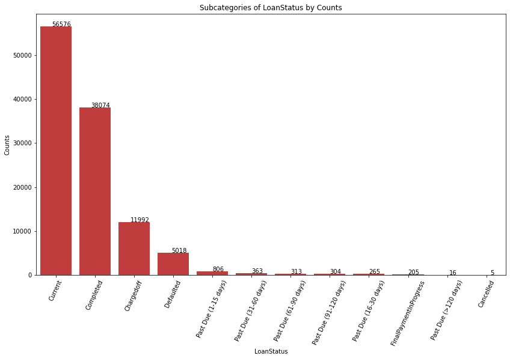

```python
# Let us make a countplot to illustrate loan status by count
plt.figure(figsize=(14,8))
make_countplot(x='LoanStatus')
```

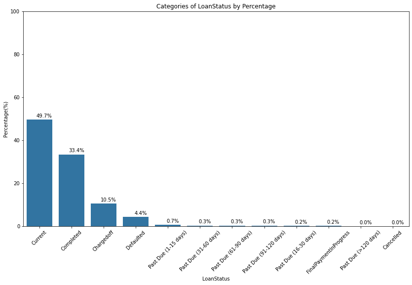

```python
#lets get a clearer picture through a percentage table and plot
#create a percent dataset for LoanStatus Categories
plt.figure(figsize=(14,8))
loanstatus_percent= makePercentTable(x='LoanStatus')
#print(loanstatus_percent)
percentplot(loanstatus_percent)
```

**Observations:**

1. The majority of Prosper Loans -56,576 loans are current loans. This represents 49.7% of all their loans.
2. A close second subcategory of Prosper loans have been completely repaid (38,074), which represents 33.4% of all their loans .

   > Together with the current loans, they both make up 83.1% of all Prosper loans.
3. A distant third subcategory of loans have been charged off (written off as losses) - a whopping 10.5%. This is apart from the 4.4% of loans that have been defaulted on.
4. Also, only a very tiny number of loans are in the delinquent subcategory, -only about 2% in total. Virtually no loan was cancelled.

> *Important secondary questions may include:

> ```
> - The income ranges, employment status and distribution of yearly salary of clients that:
>     a. have completely repaid their loan.
>     b. are currently indebted to prosperLoan Investors.
>     c. have defaulted on their loans.
>     d. have cost ProsperLoans losses.*
> ```

Question 2: a. What is the income range distribution of ProsperLoan 'debtor' clients; Are there more highly paid individuals than there are lower paid persons?  
b. What is the distribution of this population by EmploymentStatus like?

*Visualization:*

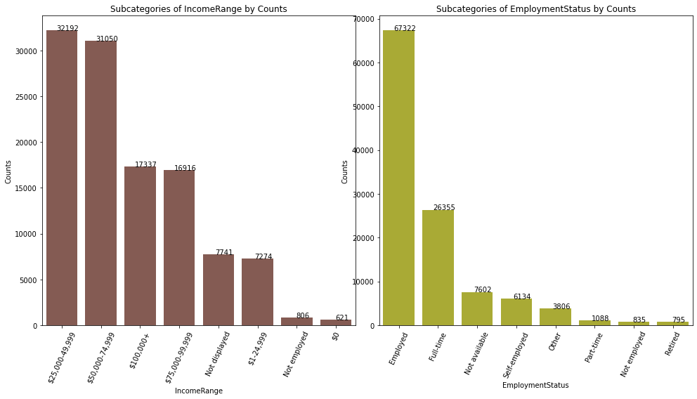

```python
# Let us make a countplot to illustrate IncomeRange and Occupation by count:

plt.figure(figsize=(14,8))

#countplot for IncomeRange
plt.subplot(1, 2, 1)
plt.tight_layout()
make_countplot(x='IncomeRange')

#countplot for Occupation
plt.subplot(1, 2, 2)
plt.tight_layout()
make_countplot(x='EmploymentStatus')
```

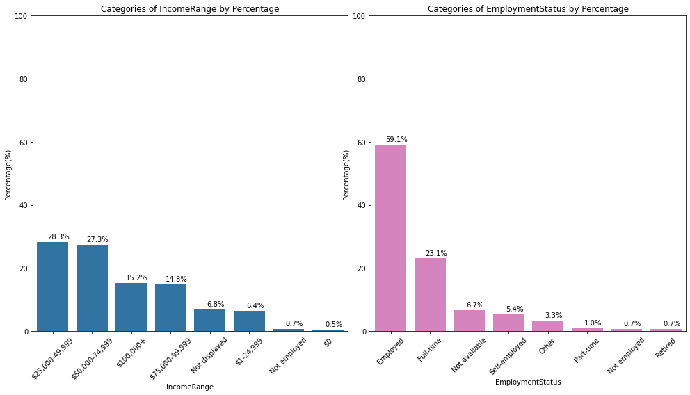

```python
#lets get a clearer picture through a percentage bar plot

plt.figure(figsize=(14,8))

#percent barplot for IncomeRange
plt.subplot(1, 2, 1)
plt.tight_layout()
percentplot(makePercentTable(x='IncomeRange'))

#percent barplot for EmploymentStatus
plt.subplot(1,2,2)
plt.tight_layout()
percentplot(makePercentTable(x='EmploymentStatus'))
```

**Observations:**

1. Over 80% of all Prosper Loans debtors are earning or earned more than \$25,000 per year.
- In the same vein, over 80\% of this same population were or are employed in some way.
- A vast majority of indebted clients (59.1\%) were or are employed. Another 23\% have or had fulltime jobs.
- A small percentage (5.4\%) were or are self-employed

> It would seem that Prosper Loan investors were more likely to lend to creditors that are or were in some form of employment.
> - Can a statistical relationship be established between Income range or yearly salary and Current/completed loans?
1. A relative minority (6.4\%)of debtors earned or earn less than \$24,999. Still, a very tiny fraction (about 1.2\% earned nothing or were unemployed (0.7\% -seen in both plots) *It seems that a tiny fraction of ProsperLoan investors were willing to risk it with clients that had or have very little means compared to the majority. Can the minority that earned from close to twenty five thousand a year to nothing be studied further?*

Question 3: a. What is the distribution of Prosper loans accross credit ratings?  
b. What is the distribution of Prosper loans among home owners and non-homeowners

*Visualization:*

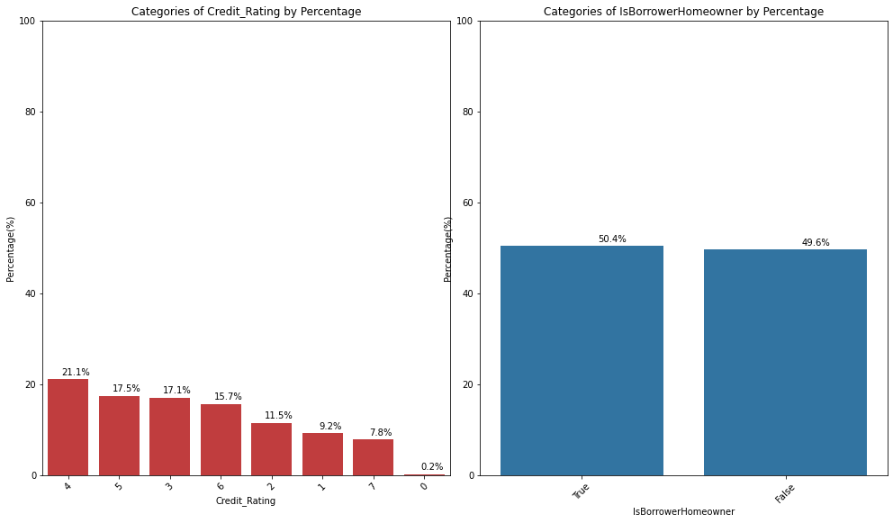

```python
#lets use a percentage bar plot

plt.figure(figsize=(14,8))

#percent barplot for Credit ratings
plt.subplot(1, 2, 1)
plt.tight_layout()
percentplot(makePercentTable(x='Credit_Rating'))

#percent barplot for Homeowner status
plt.subplot(1,2,2)
plt.tight_layout()
percentplot(makePercentTable(x='IsBorrowerHomeowner'))
```

**Observations:**

```python
loan_df_subset_copy.info()
```

```
<class 'pandas.core.frame.DataFrame'>
RangeIndex: 113937 entries, 0 to 113936
Data columns (total 21 columns):
 #   Column                       Non-Null Count   Dtype
---  ------                       --------------   -----
 0   ListingNumber                113937 non-null  int64
 1   ListingCreationDate          113937 non-null  datetime64[ns]
 2   Term                         113937 non-null  int64
 3   LoanStatus                   113937 non-null  category
 4   BorrowerState                108422 non-null  object
 5   Occupation                   110349 non-null  object
 6   EmploymentStatus             113937 non-null  category
 7   EmploymentStatusDuration     106312 non-null  float64
 8   IsBorrowerHomeowner          113937 non-null  bool
 9   DebtToIncomeRatio            105383 non-null  float64
 10  IncomeRange                  113937 non-null  category
 11  IncomeVerifiable             113937 non-null  bool
 12  StatedMonthlyIncome          113937 non-null  float64
 13  BorrowerAPR                  113912 non-null  float64
 14  BorrowerRate                 113937 non-null  float64
 15  LenderYield                  113937 non-null  float64
 16  ListingCategory              113937 non-null  category
 17  InvestmentFromFriendsCount   113937 non-null  int64
 18  InvestmentFromFriendsAmount  113937 non-null  float64
 19  Investors                    113937 non-null  int64
 20  Credit_Rating                113937 non-null  category
dtypes: bool(2), category(5), datetime64[ns](1), float64(7), int64(4), object(2)
memory usage: 12.9+ MB
```

```python
loan_df_subset_copy.DebtToIncomeRatio.unique()
```

```
array([0.17   , 0.18   , 0.06   , ..., 0.3108 , 0.07419, 0.23284])
```

**Question 4: What is the percentage distribution of the following like (in a nutshell)?:** a. Term of Loan b. Verifiable Income?

*Visualization:*

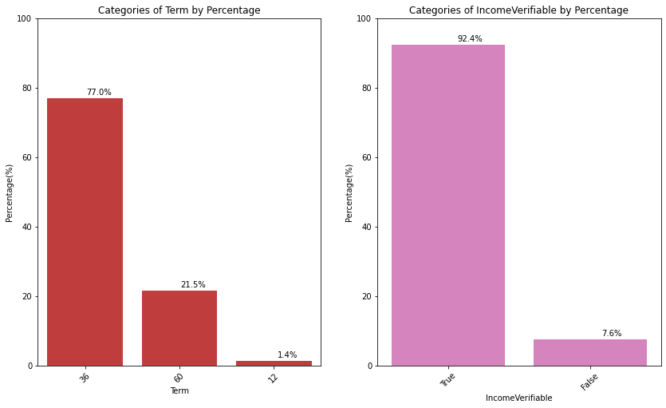

```python
#lets use a percentage bar plot

plt.figure(figsize=(14,8))

#percent barplot for Credit ratings
plt.subplot(1, 2, 1)
percentplot(makePercentTable(x='Term'))

#percent barplot for Homeowner status
plt.subplot(1,2,2)
percentplot(makePercentTable(x='IncomeVerifiable'))
```

*Let us Explore the Numeric Variables:*

```python
# first create some functions
colors = ['b', 'g', 'r', 'c', 'm', 'y', 'k',
              'tab:blue','tab:orange','tab:green','tab:red',
              'tab:purple','tab:brown','tab:pink','tab:gray',
              'tab:olive','tab:cyan']
def linear_histogram(x,xlabel,binsize,dataset=loan_df_subset_copy):
    ''' Create Plot function to make histogram charts for numeric variables using a linear xscale
        x: Numeric variable of Interest
        dataset: any dataset, but default is loan_df_subset_copy
        binsize(int): any suitable binsize
        The function creates suitably-annotated plots '''
    binsize = binsize
    bins = np.arange(0, dataset[x].max() + binsize, binsize)

    colors1 = sb.color_palette("rocket")
    color1= colors1[randrange(len(colors1))]
    color = colors[randrange(len(colors))]
    plt.ylabel('Number of Loans')
    plt.xlabel(xlabel)
    plt.title("Distribution of {categoryname} by Count".format(categoryname=x))
    plt.hist(data=dataset, x=x, color=color1, bins=bins)

def log10_histogram(x,xlabel,binsize,dataset=loan_df_subset_copy):
    ''' Create Plot function to make histogram charts for numeric variables using a log 10 xscale
        x: Numeric variable of Interest
        dataset: any dataset, but default is loan_df_subset_copy
        binsize(float): any suitable binsize
        The function creates suitably-annotated plots '''
    binsize = binsize
    bins = 10 ** np.arange(np.log10(dataset[x].min()+ 1), np.log10(dataset[x].max() + binsize), np.log10(binsize))

    colors1 = sb.color_palette("rocket")
    color1= colors1[randrange(len(colors1))]
    color = colors[randrange(len(colors))]
    plt.ylabel('Number of Loans')
    plt.xlabel(xlabel)
    plt.title("Distribution of {categoryname} by Count".format(categoryname=x))
    plt.hist(data=dataset, x=x, color=color1, bins=bins)
    plt.xscale('log')
```

**Question 5: What is the distribution of Annual Interest Rate and Annual Percentage Rate of Prosper Borrrowers' Loans**`

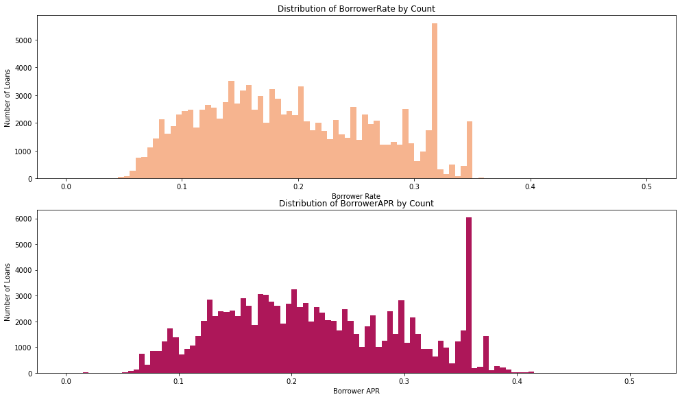

```python
plt.figure(figsize=(14,8))

#percent barplot for Credit ratings
plt.subplot(2, 1, 1)
plt.tight_layout()
linear_histogram(x='BorrowerRate', xlabel='Borrower Rate', binsize=0.005)

#percent barplot for Homeowner status
plt.subplot(2,1,2)
plt.tight_layout()
linear_histogram(x='BorrowerAPR', xlabel='Borrower APR', binsize=0.005)

# plt.subplot(2,1,1)
# linear_histogram(x='StatedMonthlyIncome', xlabel='Stated Monthly Income ($)')
```

**Observation:**

1. Both the Borrower Interest Rate and Annual Percentage Rate are skewed to the right.
- Majority of the interest rates fell between 10% (0.1) per annum and just above 30% per annum

  > Interestingly, there is a huge spike in the number of loans charged at an interest rate of just about 32% (about 5000 loans). This spike also corresponded with a spike in the number of loans charged at an Annual Percentage Rate of about 35% per annum (about 6000 loans).
1. *Outliers:* *APRs of less than 5% seem to be negative outliers and those above about 40% are positive outliers. However, the number of loans in these categories are negligible when compared to the majority.*
2. Further questions surround the phenomenom of the spikes in numbers at above 30% rates. These ought to be further explored.
- Are these business loans, loans to very credit-worthy individuals or those with poor credit ratings.
- Are they more of shorter term loans or longer term loans.
- What is the status of these loans -is there a higher rate of delinquency or default among borrowers that took at that rate?
- Did they all listed around the same time?

**Question 6: What is the distribution of the Stated Monthly Income among Prosper Loan's Borrowers?**`

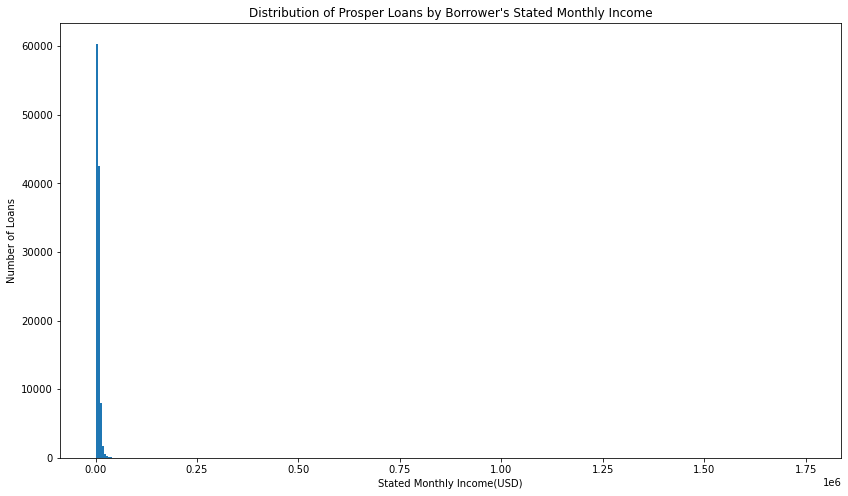

```python
#lets plot a simple histogram
plt.figure(figsize=(14,8))
plt.title('Distribution of Prosper Loans by Borrower\'s Stated Monthly Income')
plt.xlabel('Stated Monthly Income(USD)')
plt.ylabel('Number of Loans')
binsize = 5000
bins = np.arange(0, loan_df_subset_copy.StatedMonthlyIncome.max(), binsize)
plt.hist(data=loan_df_subset_copy, x='StatedMonthlyIncome', bins = bins );
```

> The plots below zoom into smaller and smaller amounts of monthly salaries to understand better the distribution of income among Prosper Loan's Borrowers.

```python
loan_df_subset_copy.StatedMonthlyIncome.value_counts()
```

```
4166.666667     3526
5000.000000     3389
3333.333333     2917
3750.000000     2428
5416.666667     2374
                ...
7069.916667        1
4266.333333        1
2211.750000        1
7032.916667        1
18756.000000       1
Name: StatedMonthlyIncome, Length: 13502, dtype: int64
```

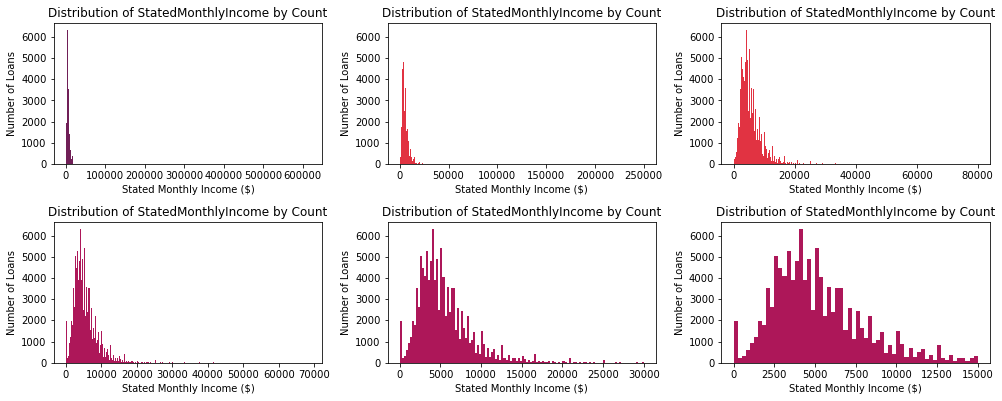

```python
# lets plot a histogram to study the stated monthly salary.
# The plot gradually zooms into the range of incomes, from the maximum to smaller and smaller amounts
# of monthly income.
upperlimits = [1.75e6, 0.25e6, 0.08e6, 0.07e6, 0.03e6, 0.015e6]
plt.figure(figsize=(14,8))
index = 1
for limit in upperlimits:
    plt.tight_layout()
    plt.subplot(3,3, index)
    linear_histogram(dataset=loan_df_subset_copy[loan_df_subset_copy['StatedMonthlyIncome'] <= upperlimits[index-1]],x='StatedMonthlyIncome', xlabel='Stated Monthly Income ($)', binsize=250)
    index = index + 1
```

**Observation II:**

1. The plot is heavily skewed to the right. Median monthly income is at about 5000 dollars.
2. Most Borrowers earned between about 2000 dollars and 8000 dolars monthly.
3. Those that earned more than about USD20,000 monthly are outliers.
4. Studying these outliers might not give important information, since they are an exclusive group that earn far more than others.

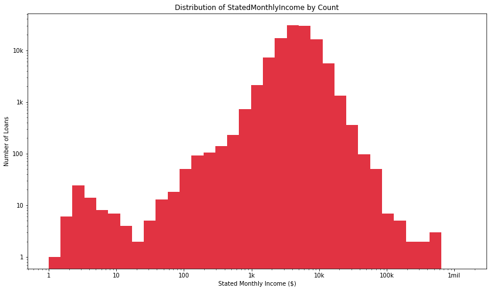

```python
# using log scales for x and y values
upperlimits = [1.75e6, 0.25e6, 0.08e6, 0.07e6, 0.03e6, 0.015e6]
plt.figure(figsize=(14,8))
index = 1
# for limit in upperlimits:
plt.yscale('log')
#plt.subplot(3,3, index)
log10_histogram(dataset=loan_df_subset_copy,x='StatedMonthlyIncome', xlabel='Stated Monthly Income ($)', binsize=1.5)
plt.xticks([1e0, 1e1,1e2, 1e3,1e4, 1e5, 1e6], ['1','10', '100', '1k','10k', '100k','1mil']);
plt.yticks([1e0, 1e1,1e2,1e3,1e4], ['1', '10','100', '1k','10k']);
```

*The plot appears more friendly, but distorts the reality of the distribution*